# Homework 3: Variable selection in Regression

Qinzhi Peng

Assigned: March 28, 2022

##### This homework is due by **11:59 pm EST on Monday, April 4**.

##### To complete this assignment, follow these steps:

1. Download the `homework3.Rmd` file from Canvas or the course website.
2. Open `homework3.Rmd` in RStudio.
3. Replace the “Your Name Here” text in the `author:` field with your own name.
4. Supply your solutions to the homework by editing `homework3.Rmd`.
5. When you have completed the homework and have **checked** that your code both runs in the Console and knits correctly when you click `Knit HTML`, rename the R Markdown file to `homework3_YourNameHere.Rmd`, and submit both the `.Rmd` file and the `.html` output file on Canvas (YourNameHere should be changed to your own name.)

### Preamble: Loading packages and data

**DO NOT CHANGE ANYTHING ABOUT THIS CODE!**

```r
library(ggplot2)
library(ISLR)
library(glmnet)
library(leaps)  # needed for regsubsets
library(boot)   # needed for cv.glm

cbPalette <- c("#999999", "#E69F00", "#56B4E9", "#009E73", "#F0E442", "#0072B2", "#D55E00", "#CC79A7")

options(scipen = 4)

# Online news share count data
set.seed(4218971)
online.news <- read.csv("http://www.andrew.cmu.edu/user/achoulde/95791/data/online_news.csv")
# subsample the data to reduce data size
num.noise <- 50
news <- data.frame(online.news,
                   matrix(rnorm(num.noise * nrow(online.news)),
                            nrow = nrow(online.news))
                   )
# Extract covariates matrix (for lasso)
news.x <- as.matrix(news[, -which(names(news) == "shares")])
# Extract response variable (for lasso)
news.y <- news$shares
```

### Data dictionary

If you want to learn more about this data set, you can have a look at the data dictionary provided here: [Data dictionary for news share data](http://www.andrew.cmu.edu/user/achoulde/95791/data/OnlineNewsPopularity.names.txt).

### Problem 1

> This question walks you through a comparison of three variable selection procedures we discussed in class.

##### **(a)** Use the `glm` command to fit a linear regression of `shares` on all the other variables in the `news` data set. Print the names of the predictors whose coefficient estimates are statistically significant at the 0.01 level. Are any of the “noise” predictors statistically significant? (Recall that “noise” predictors all have variable names of the form X#.)

```r
# Edit me
glm.fit <- glm(shares ~ ., data = news)
coef <- coef(summary(glm.fit))[, "Pr(>|t|)"]
names(coef[coef < 0.01])
```

```
##  [1] "timedelta"                     "n_tokens_title"
##  [3] "n_tokens_content"              "num_hrefs"
##  [5] "num_self_hrefs"                "data_channel_is_entertainment"
##  [7] "kw_min_avg"                    "kw_max_avg"
##  [9] "kw_avg_avg"                    "self_reference_min_shares"
## [11] "weekday_is_tuesday"            "weekday_is_thursday"
## [13] "global_subjectivity"           "X28"
```

- **Your answer here.** Yes.There is a “noise” predictor statistically significant, which is “X28”.

**Hint:** To access the P-value column of a fitted model named `my.fit`, you’ll want to look at the `coef(summary(my.fit))` object. If you are new to R, you may find [the following section of the 94-842 note](http://www.andrew.cmu.edu/user/achoulde/94842/lectures/lecture08/lecture08-94842.html#exploring-the-lm-object) helpful.

##### **(b)** Use the `cv.glm` command with 10-fold cross-validation to estimate the test error of the model you fit in part (a). Repeat with number of folds `K = 8, 12, 15, 30, 40, 60` (use a loop).

##### Calculate the standard deviation of your CV estimates divided by the mean of the estimates. This quantity is called the [coefficient of variation](https://en.wikipedia.org/wiki/Coefficient_of_variation). Do the error estimates change much across the different choices of $K$?

```r
# Edit me
set.seed(1)
folds <- c(10, 8, 12, 15, 30, 40, 60)
cv.error <- rep(0, 7)
for (i in 1:7) {
  cv.error[i] <- cv.glm(news, glm.fit, K = folds[i])$delta[1]
}
cv.error
```

```
## [1] 144925165 134799029 143593505 132811383 139137839 134942042 139023062
```

```r
cv <- sd(cv.error) / mean(cv.error)
cv
```

```
## [1] 0.03317679
```

- **Your answer here.** The error estimates not change much across the different choices of $K$, since the coefficient of variation is very low.

**Note**: This loop may take a few minutes to run. I have supplied the argument cache = TRUE in the header to prevent the code from needing to re-execute every time you knit. This code chunk will re-execute only if the code it contains gets changed.

##### **(c)** The code below produces estimates of test error using the validation set approach. Run this code 40 times (put the code in a loop). Calculate the standard deviation of the estimates divided by the mean of the estimates. Are the answers you get more or less variable than your answers from part **(b)**?

```r
####
## Modify the code below as necessary to answer the question.
####
mse <- rep(0, 40)

for (i in 1:40) {
  # Form a random split
  rand.split <- sample(cut(1:nrow(news), breaks = 2, labels = FALSE))
  # Fit model on first part
  news.glm.train <- glm(shares ~ ., data = news[rand.split == 1,])
  # Predict on the second part
  news.glm.pred <- predict(news.glm.train, newdata = news[rand.split == 2, ])
  # Calculate MSE on the second part
  mse[i] <- mean((news$shares[rand.split == 2] - news.glm.pred)^2)
}

cv <- sd(mse) / mean(mse)
cv
```

```
## [1] 3.604633
```

- **Your answer here.** I get more variable answer than the answer from part **(b)**

### Best subset selection

##### **(d)** The code below performs Best Subset Selection to identify which variables in the model are most important. We only go up to models of size 5, because beyond that the computation time starts to get excessive.

##### Which variables are included in the best model of each size? (You will want to work with the `summary(news.subset)` or `coef(news.subset, id = )` object to determine this.) Are the models all nested? That is, does the best model of size k-1 always a subset of the best model of size k? Do any “noise predictors” appear in any of the models?

```r
set.seed(12310)
# Get a smaller subset of the data to work with
# Use this ONLY for problem (d).
news.small <- news[sample(nrow(news), 2000), ]
```

```r
# Best subset selection
news.subset <- regsubsets(shares ~ .,
               data = news.small,
               nbest = 1,    # 1 best model for each number of predictors
               nvmax = 5,    # NULL for no limit on number of variables
               method = "exhaustive", really.big = TRUE)

# Add code below to answer the question
coef(news.subset, id = 1:5)
```

```
## [[1]]
## (Intercept)  kw_avg_avg
## 329.4775996   0.9123278
##
## [[2]]
##  (Intercept)   kw_max_avg   kw_avg_avg
## -414.6675637   -0.1458953    1.4151388
##
## [[3]]
##               (Intercept)                kw_max_avg                kw_avg_avg
##            -341.416136501              -0.152224307               1.375769813
## self_reference_max_shares
##               0.007606258
##
## [[4]]
##               (Intercept)                kw_max_avg                kw_avg_avg
##            -541.909614675              -0.143264847               1.326223430
## self_reference_max_shares        title_subjectivity
##               0.007487751            1066.730267608
##
## [[5]]
##               (Intercept)                kw_max_avg                kw_avg_avg
##            -530.136365889              -0.141246610               1.319478578
## self_reference_max_shares        title_subjectivity                       X23
##               0.007762227            1063.956089367            -332.898732519
```

The models are all nested, and a “noise predictors” appears the model of size 5.

### Forward Stepwise Selection

##### **(e)** Modify the code provided in part (d) to perform Forward stepwise selection instead of exhaustive search. There should be no limit on the maximum size of subset to consider.

**NOTE: You will need to swap out `news.small` for the full `news` data. You should not use `news.small` for anything other than part (d)**

```r
# Edit me
regfit.fwd <- regsubsets(shares ~ .,
               data = news.small,
               nbest = 1,
               nvmax = NULL,
               method = "forward", really.big = TRUE)
```

> Note: Parts (f) - (k) all refer to the results produced by Forward stepwise selection.

##### **(f)** For models of size 1:12, display the variables that appear in each model. Are the models all nested? Do any “noise predictors” appear in any of the models?

```r
# Edit me
regfit.fwd2 <- regsubsets(shares ~ .,
               data = news.small,
               nbest = 1,
               nvmax = 12,
               method = "forward", really.big = TRUE)
coef(regfit.fwd2, id = 1:12)
```

```
## [[1]]
## (Intercept)  kw_avg_avg
## 329.4775992   0.9123278
##
## [[2]]
##  (Intercept)   kw_max_avg   kw_avg_avg
## -414.6675652   -0.1458953    1.4151388
##
## [[3]]
##               (Intercept)                kw_max_avg                kw_avg_avg
##            -341.416137947              -0.152224307               1.375769814
## self_reference_max_shares
##               0.007606258
##
## [[4]]
##               (Intercept)                kw_max_avg                kw_avg_avg
##            -541.909616376              -0.143264847               1.326223431
## self_reference_max_shares        title_subjectivity
##               0.007487751            1066.730268959
##
## [[5]]
##               (Intercept)                kw_max_avg                kw_avg_avg
##            -530.136367590              -0.141246610               1.319478579
## self_reference_max_shares        title_subjectivity                       X23
##               0.007762227            1063.956090718            -332.898732520
##
## [[6]]
##               (Intercept)                kw_max_avg                kw_avg_avg
##            -558.932662297              -0.143461264               1.333083079
## self_reference_max_shares        title_subjectivity                       X23
##               0.007683716            1080.642527103            -332.706818562
##                       X47
##             322.141805102
##
## [[7]]
##               (Intercept)                kw_max_avg                kw_avg_avg
##            -410.613263123              -0.141617395               1.330700327
## self_reference_max_shares        weekday_is_tuesday        title_subjectivity
##               0.007702768            -788.678473085            1084.118721492
##                       X23                       X47
```

[output cut: 36 more lines]

```
##            1059.998965892             280.700239032            -312.594954993
##                       X25                       X26                       X47
##            -302.423528278             281.010126424             319.166465076
##
## [[12]]
##               (Intercept)                kw_avg_max                kw_min_avg
##            -755.544165954              -0.002525456              -0.369420003
##                kw_max_avg                kw_avg_avg self_reference_max_shares
##              -0.231162286               1.939505238               0.007667285
##        weekday_is_tuesday        title_subjectivity                        X5
##            -781.665010177            1082.431039844             281.250179835
##                       X23                       X25                       X26
##            -307.459221002            -306.203639949             276.404218173
##                       X47
##             319.143780383
```

- **Your answer here.** The models are all nested. “Noise predictors” appear in the models when size are larger than 4.

##### **(g)** When you run `summary()` on a regsubsets object you get a bunch of useful values. Construct a plot showing R-squared on the y-axis and model size on the x-axis. Use appropriate axis labels. Does R-squared always increase as we increase the model size? Explain.

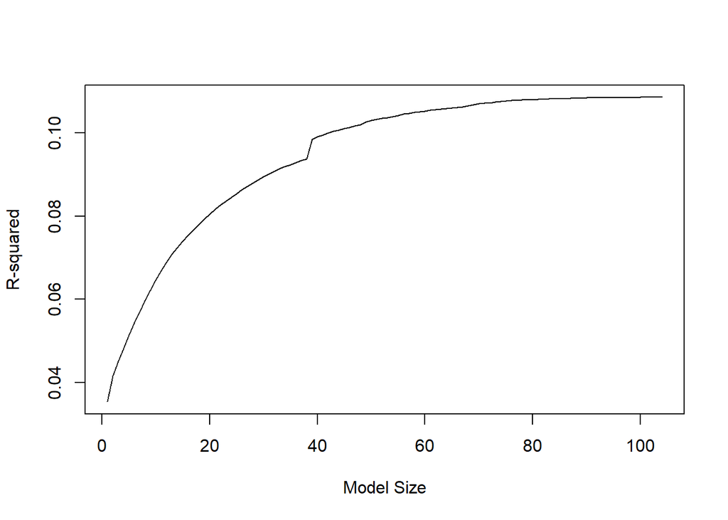

```r
# Edit me
reg.summary <- summary(regfit.fwd)
plot(reg.summary$rsq,xlab="Model Size",ylab="R-squared",type="l")
```

- **Your answer here.** R-squared always increases as we increase the model size. According to the formula of R-squared, when we add a new variable into the model, if the estimated coefficient takes a zero value, the SSE and the R square will stay unchanged; if the estimated coefficient takes a nonzero value, the SSE will decrease and R square will increase.

##### **(h)** Construct a plot showing Residual sum of squares on the y-axis and model size on the x-axis. Does the RSS always decrease as we increase the model size? Explain.

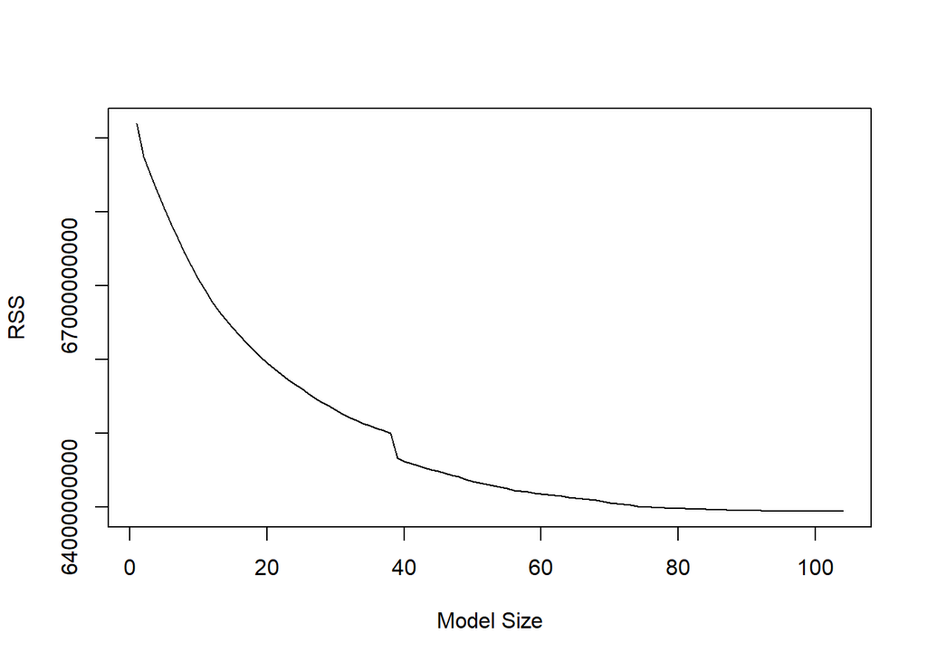

```r
# Edit me
plot(reg.summary$rss,xlab="Model Size",ylab="RSS",type="l")
```

- **Your answer here.** The RSS always decreases as we increase the model size. The explanation is same as part h. According to the formula of RSS, Whenever we add a new variable into the model, the SSE will always stay unchanged or decrease.

##### **(i)** [2 points] Construct a plot showing AIC (aka Mallows Cp) on the y-axis and model size on the x-axis. Is the curve monotonic? Explain. What model size minimizes AIC? How many “noise predictors” get included in this model?

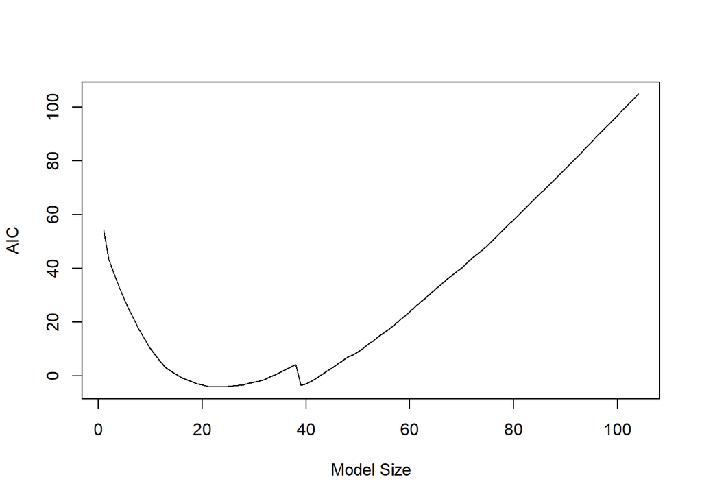

```r
# Edit me
plot(reg.summary$cp,xlab="Model Size",ylab="AIC",type='l')
```

```r
which.min(reg.summary$cp)
```

```
## [1] 23
```

```r
names(coef(regfit.fwd, 23))
```

```
##  [1] "(Intercept)"               "num_hrefs"
##  [3] "num_imgs"                  "average_token_length"
##  [5] "kw_avg_min"                "kw_avg_max"
##  [7] "kw_min_avg"                "kw_max_avg"
##  [9] "kw_avg_avg"                "self_reference_max_shares"
## [11] "weekday_is_tuesday"        "weekday_is_wednesday"
## [13] "min_negative_polarity"     "max_negative_polarity"
## [15] "title_subjectivity"        "X1"
## [17] "X5"                        "X23"
## [19] "X25"                       "X26"
## [21] "X38"                       "X41"
## [23] "X47"                       "X48"
```

##### **(j)** Construct a plot showing BIC on the y-axis and model size on the x-axis. Is the curve monotonic? Explain. What model size minimizes BIC? How many “noise predictors” get included in this model?

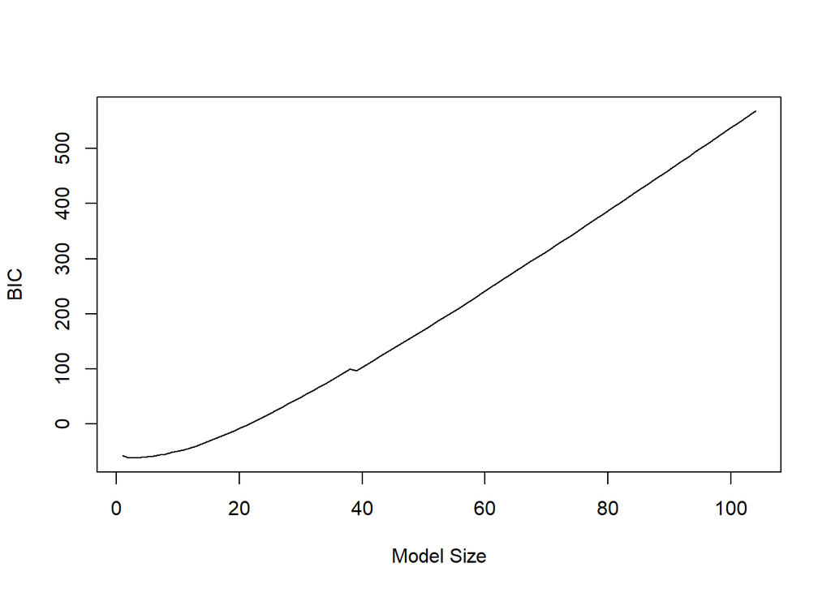

```r
# Edit me
plot(reg.summary$bic,xlab="Model Size",ylab="BIC",type='l')
```

```r
which.min(reg.summary$bic)
```

```
## [1] 2
```

```r
names(coef(regfit.fwd, 2))
```

```
## [1] "(Intercept)" "kw_max_avg"  "kw_avg_avg"
```

- **Your answer here.** The curve is not monotonic.The BIC also has a penalty factor, just like the AIC. But in this data set, the BIC penalty factor is larger than the AIC, which means BIC will choose a simpler model. 2 model size minimizes BIC. There are no “noise predictors” included in this model.

##### **(k)** [2 points] Compare the models selected by AIC and BIC. Is one a subset of the other? Which criterion selects the smaller model? Does that criterion always result in a smaller model, or is does this happen just by coincidence on the `news` data? Explain.

- **Your answer here.** The model selected by BIC is one a subset of the model selected by AIC. The BIC selects the smaller model. According to the formulas of AIC and BIC, when the number of sample points is equal or larger than 8, the BIC penalty factor will be larger than the AIC, which means the BIC will select a smaller model. For the `news` data, we have lots of sample points, thus the BIC selects a smaller model.

### Lasso

> For the Lasso problems below, you may find it helpful to review the code examples in the [Linear regression with glmnet](https://web.stanford.edu/~hastie/glmnet/glmnet_alpha.html#lin) vignette. Running the glmnet command `glmnet(x = X, y = y)` where `y` is your response vector and `X` is your covariates matrix will fit a Lasso.

##### **(l)** Variables `news.x` and `news.y` were pre-constructed in the preamble to this assignment. Use the `glmnet` command to fit a Lasso to this data. Call the result `news.lasso`.

```r
# Edit me
news.lasso <- glmnet(news.x, news.y)
news.lasso
```

```
##
## Call:  glmnet(x = news.x, y = news.y)
##
##     Df %Dev  Lambda
## 1    0 0.00 1284.00
## 2    1 0.21 1170.00
## 3    1 0.38 1066.00
## 4    1 0.52  971.10
## 5    1 0.64  884.80
## 6    1 0.74  806.20
## 7    1 0.82  734.60
## 8    2 0.91  669.30
## 9    2 0.99  609.90
## 10   3 1.08  555.70
## 11   3 1.16  506.30
```

[output cut: 87 more lines]

##### **(m)** It turns out that `news.lasso` contains model fits for an entire sequence of $\lambda$ values. Look at the `news.lasso$lambda` attribute. How many $\lambda$ values do we have model fits for?

```r
# Edit me
news.lasso$lambda
```

```
##  [1] 1283.7487255 1169.7040269 1065.7907450  971.1088326  884.8382004
##  [6]  806.2316134  734.6082189  669.3476494  609.8846491  555.7041777
## [11]  506.3369502  461.3553711  420.3698314  383.0253342  348.9984192
## [16]  317.9943615  289.7446188  264.0045055  240.5510728  219.1811785
## [21]  199.7097267  181.9680650  165.8025236  151.0730844  137.6521680
## [26]  125.4235287  114.2812481  104.1288170   94.8782999   86.4495732
## [31]   78.7696314   71.7719545   65.3959318   59.5863375   54.2928515
## [36]   49.4696242   45.0748791   41.0705511   37.4219565   34.0974931
## [41]   31.0683658   28.3083378   25.7935031   23.5020793   21.4142194
## [46]   19.5118392   17.7784611   16.1990717   14.7599908   13.4487539
## [51]   12.2540036   11.1653917   10.1734891    9.2697044    8.4462094
## [56]    7.6958714    7.0121914    6.3892477    5.8216445    5.3044657
## [61]    4.8332315    4.4038606    4.0126337    3.6561624    3.3313590
## [66]    3.0354103    2.7657528    2.5200509    2.2961766    2.0921906
## [71]    1.9063261    1.7369734    1.5826654    1.4420658    1.3139566
## [76]    1.1972284    1.0908699    0.9939600    0.9056593    0.8252031
## [81]    0.7518943    0.6850981    0.6242359    0.5687805    0.5182516
## [86]    0.4722115    0.4302616    0.3920383    0.3572107    0.3254771
## [91]    0.2965626    0.2702168    0.2462115    0.2243387    0.2044091
## [96]    0.1862500    0.1697040    0.1546280
```

- **Your answer here.** We have 98 $\lambda$ values.

##### **(n)** The `coef(news.lasso, s = )` will print out the estimated coefficients for our model at any lambda value `s`. Display the coefficient estimates for the 20th value of $\lambda$ from part (l). How many coefficients in this model are non-zero? How many of the non-zero coefficients come from “noise predictors”?

```r
# Edit me
lasso.coef <- coef(news.lasso)[,20]
lasso.coef
```

```
##                   (Intercept)                     timedelta
##                1025.831452587                   0.041001734
##                n_tokens_title              n_tokens_content
##                   0.000000000                   0.000000000
##               n_unique_tokens              n_non_stop_words
##                   0.000000000                   0.000000000
##      n_non_stop_unique_tokens                     num_hrefs
##                   0.000000000                  14.321747600
##                num_self_hrefs                      num_imgs
##                   0.000000000                   0.000000000
##                    num_videos          average_token_length
##                   0.000000000                   0.000000000
##                  num_keywords data_channel_is_entertainment
##                   0.000000000                -187.513999488
##           data_channel_is_bus        data_channel_is_socmed
##                   0.000000000                   0.000000000
##          data_channel_is_tech         data_channel_is_world
##                   0.000000000                   0.000000000
##                    kw_min_min                    kw_max_min
##                   0.000000000                   0.000000000
##                    kw_avg_min                    kw_min_max
##                   0.000000000                   0.000000000
##                    kw_max_max                    kw_avg_max
##                   0.000000000                   0.000000000
##                    kw_min_avg                    kw_max_avg
##                   0.000000000                   0.000000000
##                    kw_avg_avg     self_reference_min_shares
##                   0.628667663                   0.014962558
##     self_reference_max_shares    self_reference_avg_sharess
##                   0.000000000                   0.001743996
##            weekday_is_tuesday          weekday_is_wednesday
##                   0.000000000                   0.000000000
##           weekday_is_thursday             weekday_is_friday
##                   0.000000000                   0.000000000
##                    is_weekend                        LDA_01
##                   0.000000000                   0.000000000
##                        LDA_02                        LDA_03
##                -468.678731350                1119.039012600
##                        LDA_04           global_subjectivity
##                   0.000000000                   0.000000000
```

[output cut: 51 more lines]

```
##                   0.000000000                   0.000000000
##                           X38                           X39
##                   0.000000000                   0.000000000
##                           X40                           X41
##                   0.000000000                   0.000000000
##                           X42                           X43
##                   0.000000000                   0.000000000
##                           X44                           X45
##                   0.000000000                   0.000000000
##                           X46                           X47
##                   0.000000000                   0.000000000
##                           X48                           X49
##                   0.000000000                   0.000000000
##                           X50
##                   0.000000000
```

```r
length(lasso.coef[lasso.coef != 0])
```

```
## [1] 10
```

- **Your answer here.** 10 coefficients in this model are non-zero. There are no non-zero coefficients coming from “noise predictors”.

##### **(o)** Run the `plot` command on your `news.lasso` object to get a regularization plot. Review the help file for `plot.glmnet` to figure out how to set “norm” as the x-axis variable option, and how to add labels to the curves. In this parameterization of the x-axis, is the model fit getting more complex or less complex as the x-axis variable increases?

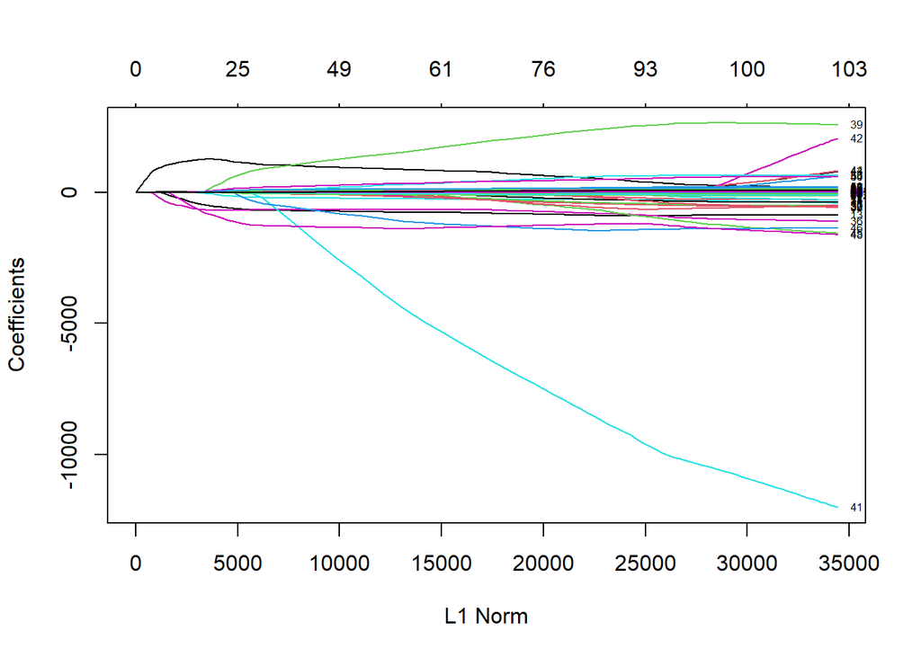

```r
# Edit me
plot(news.lasso, xvar="norm", label = TRUE)
```

- **Your answer here.** The model fit is getting more complex as the x-axis variable increases.

##### **(p)** `cv.glmnet(x, y)` will perform 10-fold cross-validation on the entire sequence of models fit by `glmnet(x, y)`. Use the `cv.glmnet` command to perform cross-validation. Save the results in a variable called `news.lasso.cv`. Run the `plot()` command to get a CV error plot.

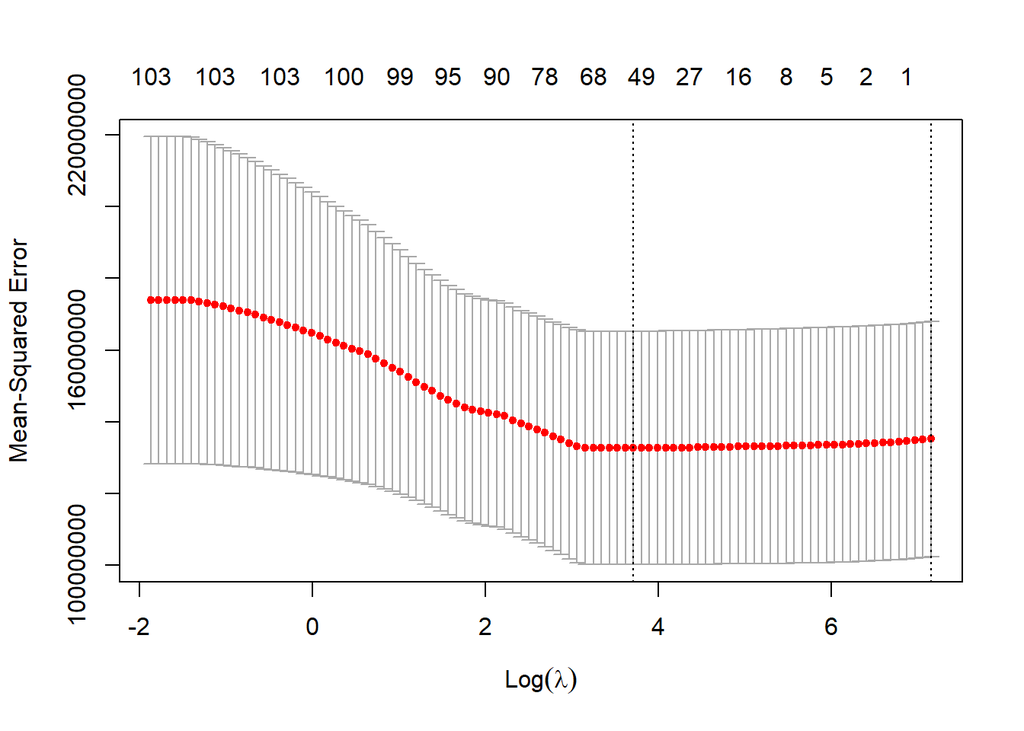

```r
# Edit me
set.seed(1)
news.lasso.cv <- cv.glmnet(news.x, news.y)
plot(news.lasso.cv)
```

##### **(q)** Use the `news.lasso.cv` object to figure out the value of $\lambda$ that minimizes CV error. Which value of $\lambda$ does the 1-SE rule tell us to use? How many non-zero variables are selected by the min-CV rule and the 1-SE rule? What is the estimated CV error for both of these models? How many “noise predictors” get included in each model?

```r
# Edit me
bestlam = news.lasso.cv$lambda.min
bestlam
```

```
## [1] 41.07055
```

```r
selam = news.lasso.cv$lambda.1se
selam
```

```
## [1] 1283.749
```

```r
bestlam.coef <- coef(news.lasso.cv, s = "lambda.min")
length(bestlam.coef[bestlam.coef != 0])
```

```
## <sparse>[ <logic> ] : .M.sub.i.logical() maybe inefficient
```

```
## [1] 53
```

```r
selam.coef <- coef(news.lasso.cv, s = "lambda.1se")
length(selam.coef[selam.coef != 0])
```

```
## <sparse>[ <logic> ] : .M.sub.i.logical() maybe inefficient
```

```
## [1] 1
```

```r
news.lasso.cv$cvm[news.lasso.cv$lambda == news.lasso.cv$lambda.min]
```

```
## [1] 132698465
```

```r
news.lasso.cv$cvm[news.lasso.cv$lambda == news.lasso.cv$lambda.1se]
```

```
## [1] 135168827
```

```r
bestlam.coef
```

```
## 105 x 1 sparse Matrix of class "dgCMatrix"
##                                            s1
## (Intercept)                   -1271.365784034
## timedelta                         1.280490089
## n_tokens_title                   80.068013923
## n_tokens_content                  0.098853962
## n_unique_tokens                   .
## n_non_stop_words                  .
## n_non_stop_unique_tokens          .
## num_hrefs                        24.801130031
## num_self_hrefs                  -34.862994450
## num_imgs                         10.054068819
## num_videos                        .
## average_token_length           -249.549268692
## num_keywords                     45.900861263
## data_channel_is_entertainment  -754.901922654
## data_channel_is_bus               .
## data_channel_is_socmed            .
## data_channel_is_tech              .
## data_channel_is_world             .
## kw_min_min                        0.570826209
## kw_max_min                        .
## kw_avg_min                        .
## kw_min_max                       -0.001801066
## kw_max_max                        .
## kw_avg_max                        .
## kw_min_avg                       -0.166069053
## kw_max_avg                       -0.109647081
## kw_avg_avg                        1.224668638
## self_reference_min_shares         0.021978068
## self_reference_max_shares         0.002436317
## self_reference_avg_sharess        .
## weekday_is_tuesday             -139.555229284
## weekday_is_wednesday             -0.271901854
## weekday_is_thursday            -158.159861704
## weekday_is_friday               -96.182231236
## is_weekend                      113.268371557
## LDA_01                            .
## LDA_02                         -656.589340692
## LDA_03                          868.414616262
```

[output cut: 52 more lines]

```
## X36                              36.084058564
## X37                               .
## X38                               .
## X39                             -26.165094292
## X40                             -21.250840036
## X41                               1.339476000
## X42                               6.965485837
## X43                               .
## X44                               .
## X45                             -17.962678945
## X46                               .
## X47                               .
## X48                             -60.695328498
## X49                               .
## X50                              24.476206121
```

```r
selam.coef
```

```
## 105 x 1 sparse Matrix of class "dgCMatrix"
##                                    s1
## (Intercept)                   3395.38
## timedelta                        .
## n_tokens_title                   .
## n_tokens_content                 .
## n_unique_tokens                  .
## n_non_stop_words                 .
## n_non_stop_unique_tokens         .
## num_hrefs                        .
## num_self_hrefs                   .
## num_imgs                         .
## num_videos                       .
## average_token_length             .
## num_keywords                     .
## data_channel_is_entertainment    .
## data_channel_is_bus              .
## data_channel_is_socmed           .
## data_channel_is_tech             .
## data_channel_is_world            .
## kw_min_min                       .
## kw_max_min                       .
## kw_avg_min                       .
## kw_min_max                       .
## kw_max_max                       .
## kw_avg_max                       .
## kw_min_avg                       .
## kw_max_avg                       .
## kw_avg_avg                       .
## self_reference_min_shares        .
## self_reference_max_shares        .
## self_reference_avg_sharess       .
## weekday_is_tuesday               .
## weekday_is_wednesday             .
## weekday_is_thursday              .
## weekday_is_friday                .
## is_weekend                       .
## LDA_01                           .
## LDA_02                           .
## LDA_03                           .
```

[output cut: 52 more lines]

```
## X36                              .
## X37                              .
## X38                              .
## X39                              .
## X40                              .
## X41                              .
## X42                              .
## X43                              .
## X44                              .
## X45                              .
## X46                              .
## X47                              .
## X48                              .
## X49                              .
## X50                              .
```

- **Your answer here.** When $\lambda$ = 41.07055, the model gives minimum CV error. Using the 1-SE rule, we choose the model with $\lambda$ = 1283.749. There are 53 non-zero variables are selected by the min-CV rule, and 1 non-zero variable is selected by the 1-SE rule. The estimated CV error for the min-CV rule model is 132698465, and the estimated CV error for the 1-SE rule model is 135168827. In the min-CV rule model, we have 21 “noise predictors”, but in the 1-SE rule model, we have no “noise predictors”.

##### **(r)** How does the CV error of the lambda-min model compare to the 10-fold CV error of the linear model you fit in part (a)? Does it look like a model with a small number of predictors does as good a job of predicting share count?

```r
# Edit me
news.lasso.cv$cvm[news.lasso.cv$lambda == news.lasso.cv$lambda.min]
```

```
## [1] 132698465
```

```r
cv.error[1]
```

```
## [1] 144925165
```

- **Your answer here.** The CV error of the lambda-min model is smaller than the 10-fold CV error of the linear model in part (a). It looks like a model with a small number of predictors does as good a job of predicting share count.